# Amandafwu_OriginalHomeworkCode_02

Amanda Wu

2023-09-28

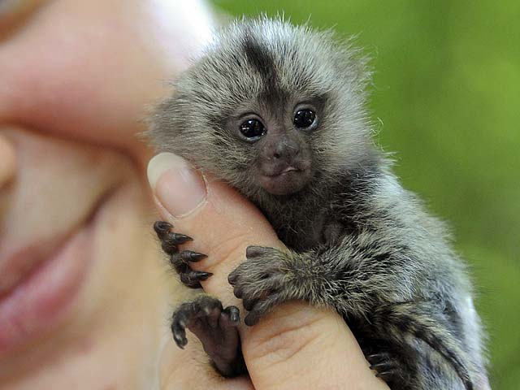

baby titi monkey <3

## Prompt

Every Saturday morning, at the same time, a primatologist goes and sits in the forest to listen for titi monkey calls, counting the number of calls they hear in a 2 hour window from 5am to 7am. Based on previous knowledge, she believes that the mean number of calls she will hear in that time is exactly 15. Let X represent the appropriate Poisson random variable of the number of calls heard in each monitoring session.

## Question 1

What is the probability that she will hear more than 8 calls during any given session?

```r
x <- 0:8
l <- 15
probset <- 1 - dpois(x, lambda = l)
probset
```

```
## [1] 0.9999997 0.9999954 0.9999656 0.9998279 0.9993547 0.9980642 0.9951605
## [8] 0.9896297 0.9805557
```

## Question 2

What’s the probability that she will hear no calls in one session?

```r
x <- 0
l <- 15
probset <- dpois(x, lambda = l)
probset
```

```
## [1] 3.059023e-07
```

## Question 3

What is the probability that she will hear exactly 3 calls in a session?

```r
x <- 3
l <- 15
probset <- dpois(x, lambda = l)
probset
```

```
## [1] 0.0001720701
```

## Question 4

Plot the relevant Poisson mass function over the values in range 0 ≤ x ≤ 30.

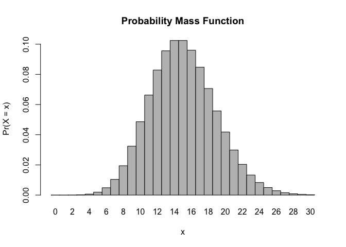

```r
x <- 0:30
l <- 15
probset <- dpois(x, lambda = l)
barplot(probset, names.arg = x, space = 0, xlab = "x", ylab = "Pr(X = x)", main = "Probability Mass Function")
```

## Question 5

Simulate 104 results from this distribution (i.e., 2 years of Saturday monitoring sessions).

```r
lambda <- 15
stimulation <- rpois(104, lambda)
stimulation
```

```
##   [1] 21 12 21 21 15 10 21  9 13 20 13 17 15 17 23 13 10 20 12 12 15 13 13 18 22
##  [26] 18 16 14 14 14 19 12 17 15 12 24 10 12 17 16 11 11 16 17 13 16  9 20 14 13
##  [51] 17  9 21 16 13 11 16  7 11 16  8 21 14 16 15 20 10 13 14 10 15 19 14  9 20
##  [76] 13 18 10 15 22 11 12 11 14 19 12 23 15 17 12 18 12 16 21 17 15 15 12 15 18
## [101] 18 10 11 14
```

## Question 6

Plot the simulated results using hist() and use xlim() to set the horizontal limits to be from 0 to 30. How does your histogram compare to the shape of the probability mass function you plotted above?

[figure not shown]

```r
x <- 0:30
l <- 15
probset <- dpois(x, lambda = l)
hist(probset, probability = TRUE, xlab = "# of calls", ylab = "probability", main = "Histogram", xlim = c(0,30) )
```